# Customer Segmentation - Connie Xavier

## Problem Definition and Information

### Context

AllLife Bank wants to focus on its credit card customer base in the next financial year to improve market penetration. The Marketing team proposes to run personalized campaigns to target new customers as well as upsell to existing customers. Another insight from the market research was that the customers perceive the support services of the bank poorly. Based on this, the Operations team wants to upgrade the service delivery model, to ensure that customer queries are resolved faster. Head of Marketing and Head of Delivery both decide to reach out to the Data Science team for help.

As a Data scientist at AllLife Bank, I need to identify different segments in the existing customer base, based on their spending patterns as well as past interactions with the bank and provide recommendations to the bank on how to better market to and service these customers.

### Objective

To explore and visualize the data, use clustering algorithms to segment the existing customers, and generate a set of insights and recommendations that will help the bank.

### Key Questions

1. Is there a good clustering algorithm to segment the existing customers?
2. How many different groups/clusters of countries can be found from the data?
3. What are the key factors distinguishing the different clusters of customers?
4. What improvements can the bank make to market and service these customers?

### Data Information

Each record in the database represents a customer's information. A detailed data dictionary can be found below.

**Data Dictionary**

- Sl_No: Primary key of the records
- Customer Key: Customer identification number
- Average Credit Limit: Average credit limit of each customer for all credit cards
- Total credit cards: Total number of credit cards possessed by the customer
- Total visits bank: Total number of visits that customer made (yearly) personally to the bank
- Total visits online: Total number of visits or online logins made by the customer (yearly)
- Total calls made: Total number of calls made by the customer to the bank or its customer service department (yearly)

# ----------------------------------------------------------------------------------------

## Part 1: Overview of Data

```python
# import relevant libraries
# Libraries to help with reading and manipulating data
import numpy as np
import pandas as pd

# Libraries to help with data visualization
import matplotlib.pyplot as plt
import seaborn as sns

# Removes the limit for the number of displayed columns
pd.set_option("display.max_columns", None)
# Sets the limit for the number of displayed rows
pd.set_option("display.max_rows", 200)

# to scale the data using z-score
from sklearn.preprocessing import StandardScaler

# to compute distances
from scipy.spatial.distance import pdist

# to compute distances
from scipy.spatial.distance import cdist

# to perform k-means clustering and compute silhouette scores
from sklearn.cluster import KMeans
from sklearn.metrics import silhouette_score

# to visualize the elbow curve and silhouette scores
from yellowbrick.cluster import KElbowVisualizer, SilhouetteVisualizer

# to perform hierarchical clustering, compute cophenetic correlation, and create dendrograms
from sklearn.cluster import AgglomerativeClustering
from scipy.cluster.hierarchy import dendrogram, linkage, cophenet

# to perform PCA
from sklearn.decomposition import PCA

# To supress warnings
import warnings

warnings.filterwarnings("ignore")

# This will help in making the Python code more structured automatically (good coding practice)
%load_ext nb_black
```

```
The nb_black extension is already loaded. To reload it, use:
  %reload_ext nb_black
```

```python
# load the data
data = pd.read_excel("Credit Card Customer Data.xlsx")
```

```python
# check a sample of the data to make sure it came in correctly
data.sample(n=10, random_state=1)
```

|  | Sl_No | Customer Key | Avg_Credit_Limit | Total_Credit_Cards | Total_visits_bank | Total_visits_online | Total_calls_made |
| --- | --- | --- | --- | --- | --- | --- | --- |
| 547 | 548 | 38125 | 26000 | 4 | 5 | 2 | 4 |
| 353 | 354 | 94437 | 9000 | 5 | 4 | 1 | 3 |
| 499 | 500 | 65825 | 68000 | 6 | 4 | 2 | 2 |
| 173 | 174 | 38410 | 9000 | 2 | 1 | 5 | 8 |
| 241 | 242 | 81878 | 10000 | 4 | 5 | 1 | 3 |
| 341 | 342 | 70779 | 18000 | 4 | 3 | 2 | 0 |
| 647 | 648 | 79953 | 183000 | 9 | 0 | 9 | 2 |
| 218 | 219 | 28208 | 19000 | 3 | 1 | 5 | 7 |
| 120 | 121 | 16577 | 10000 | 4 | 2 | 4 | 6 |
| 134 | 135 | 31256 | 13000 | 4 | 1 | 5 | 7 |

- Looks like all the features came in.
- S1_No and Customer Key do not contain relevant information for the clustering algorithm and can be dropped.
- No missing values appear in this sample section

```python
# check the shape
print(f"There are {data.shape[0]} rows and {data.shape[1]} columns in the data.")
```

```
There are 660 rows and 7 columns in the data.
```

- There are likely to be duplicates when looking at the financial information and number of interactions for different customers. So we will check the Sl_No and Customer Key values instead.

```python
# check for duplicates in Sl_No
print(f"There are {data.Sl_No.duplicated().sum()} duplicated values in Sl_No.")
```

```
There are 0 duplicated values in Sl_No.
```

```python
# check for duplicates in Customer Key
print(
    f"There are {data['Customer Key'].duplicated().sum()} duplicated values in Customer Key."
)
```

```
There are 5 duplicated values in Customer Key.
```

```python
# look at the duplicate Customer Key values and corresponding data
data[data.duplicated(["Customer Key"], keep=False)].sort_values("Customer Key")
```

|  | Sl_No | Customer Key | Avg_Credit_Limit | Total_Credit_Cards | Total_visits_bank | Total_visits_online | Total_calls_made |
| --- | --- | --- | --- | --- | --- | --- | --- |
| 48 | 49 | 37252 | 6000 | 4 | 0 | 2 | 8 |
| 432 | 433 | 37252 | 59000 | 6 | 2 | 1 | 2 |
| 4 | 5 | 47437 | 100000 | 6 | 0 | 12 | 3 |
| 332 | 333 | 47437 | 17000 | 7 | 3 | 1 | 0 |
| 411 | 412 | 50706 | 44000 | 4 | 5 | 0 | 2 |
| 541 | 542 | 50706 | 60000 | 7 | 5 | 2 | 2 |
| 391 | 392 | 96929 | 13000 | 4 | 5 | 0 | 0 |
| 398 | 399 | 96929 | 67000 | 6 | 2 | 2 | 2 |
| 104 | 105 | 97935 | 17000 | 2 | 1 | 2 | 10 |
| 632 | 633 | 97935 | 187000 | 7 | 1 | 7 | 0 |

- The customers with the same Customer Key have different data for the rest of the features. The duplicate values might correspond to customer profile changes, and as such, there is no need to delete these records as these are actual occurrences at some point in the time. The column can be dropped during the analysis.

```python
# check for duplicate rows
print(f"There are {data.duplicated().sum()} duplicated rows in the data.")
```

```
There are 0 duplicated rows in the data.
```

```python
# dropping irrelevant columns
df = data.copy()
df = df.drop(["Sl_No", "Customer Key"], axis=1)
```

```python
# check datatypes of the columns and which columns have null values
df.info()
```

```
<class 'pandas.core.frame.DataFrame'>
RangeIndex: 660 entries, 0 to 659
Data columns (total 5 columns):
 #   Column               Non-Null Count  Dtype
---  ------               --------------  -----
 0   Avg_Credit_Limit     660 non-null    int64
 1   Total_Credit_Cards   660 non-null    int64
 2   Total_visits_bank    660 non-null    int64
 3   Total_visits_online  660 non-null    int64
 4   Total_calls_made     660 non-null    int64
dtypes: int64(5)
memory usage: 25.9 KB
```

```python
# check which columns have null values
df.isna().sum()[df.isna().sum() > 0]
```

```
Series([], dtype: int64)
```

- All features have 660 values, so there are no null values.
- All variables are integer type.

```python
# look at the statistical summary of the data
df.describe().T
```

|  | count | mean | std | min | 25% | 50% | 75% | max |
| --- | --- | --- | --- | --- | --- | --- | --- | --- |
| Avg_Credit_Limit | 660.0 | 34574.242424 | 37625.487804 | 3000.0 | 10000.0 | 18000.0 | 48000.0 | 200000.0 |
| Total_Credit_Cards | 660.0 | 4.706061 | 2.167835 | 1.0 | 3.0 | 5.0 | 6.0 | 10.0 |
| Total_visits_bank | 660.0 | 2.403030 | 1.631813 | 0.0 | 1.0 | 2.0 | 4.0 | 5.0 |
| Total_visits_online | 660.0 | 2.606061 | 2.935724 | 0.0 | 1.0 | 2.0 | 4.0 | 15.0 |
| Total_calls_made | 660.0 | 3.583333 | 2.865317 | 0.0 | 1.0 | 3.0 | 5.0 | 10.0 |

Significant observations:

- The min number of bank visits, online visits, and calls made are 0, which is possible.
- The min number of total credit cards is 1, which makes sense since this is a database of existing credit card customer data.
- The max of Avg_Credit_Limit reaches 200,000. We will need to see if this is an outlier.
- The mean for Total_Credit_Cards is slightly less than the median.
- Avg_Credit_Limit, Total_visits_bank, Total_visits_online, and Total_calls_made have a higher mean than median value.
- Avg_Credit_Limit, Total_Credit_Cards, Total_visits_online, and Total_calls_made appear skewed to the right since there is a large gap between the 75% and max values. We will check for outliers in this data.

## Part 2: Exploratory Data Analysis and Data Preprocessing

Exploratory data analysis and data preprocessing involving outlier detection and treatment often depend on each other, so they are included together below.

### Univariate Analysis

```python
# function to plot a boxplot and a histogram along the same scale.


def histogram_boxplot(data, feature, figsize=(12, 7), kde=True, bins=None):
    """
    Boxplot and histogram combined

    data: dataframe
    feature: dataframe column
    figsize: size of figure (default (12,7))
    kde: whether to the show density curve (default False)
    bins: number of bins for histogram (default None)
    """
    f2, (ax_box2, ax_hist2) = plt.subplots(
        nrows=2,  # Number of rows of the subplot grid= 2
        sharex=True,  # x-axis will be shared among all subplots
        gridspec_kw={"height_ratios": (0.25, 0.75)},
        figsize=figsize,
    )  # creating the 2 subplots
    sns.boxplot(
        data=data, x=feature, ax=ax_box2, showmeans=True, color="violet"
    )  # boxplot will be created and a star will indicate the mean value of the column
    sns.histplot(
        data=data, x=feature, kde=kde, ax=ax_hist2, bins=bins, palette="winter"
    ) if bins else sns.histplot(
        data=data, x=feature, kde=kde, ax=ax_hist2
    )  # For histogram
    ax_hist2.axvline(
        data[feature].mean(), color="green", linestyle="--"
    )  # Add mean to the histogram
    ax_hist2.axvline(
        data[feature].median(), color="black", linestyle="-"
    )  # Add median to the histogram
```

```python
# function to create labeled barplots


def labeled_barplot(data, feature, perc=False, n=None):
    """
    Barplot with percentage at the top

    data: dataframe
    feature: dataframe column
    perc: whether to display percentages instead of count (default is False)
    n: displays the top n category levels (default is None, i.e., display all levels)
    """

    total = len(data[feature])  # length of the column
    count = data[feature].nunique()
    if n is None:
        plt.figure(figsize=(count + 1, 5))
    else:
        plt.figure(figsize=(n + 1, 5))

    plt.xticks(rotation=90, fontsize=15)
    ax = sns.countplot(
        data=data,
        x=feature,
        palette="Paired",
        order=data[feature].value_counts().index[:n].sort_values(),
    )

    for p in ax.patches:
        if perc == True:
            label = "{:.1f}%".format(
                100 * p.get_height() / total
            )  # percentage of each class of the category
        else:
            label = p.get_height()  # count of each level of the category

        x = p.get_x() + p.get_width() / 2  # width of the plot
        y = p.get_height()  # height of the plot

        ax.annotate(
            label,
            (x, y),
            ha="center",
            va="center",
            size=12,
            xytext=(0, 5),
            textcoords="offset points",
        )  # annotate the percentage

    plt.show()  # show the plot
```

```
Avg_Credit_Limit
```

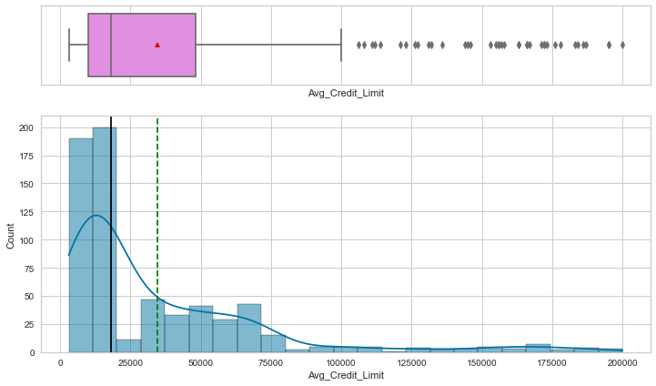

```
Total_Credit_Cards
```

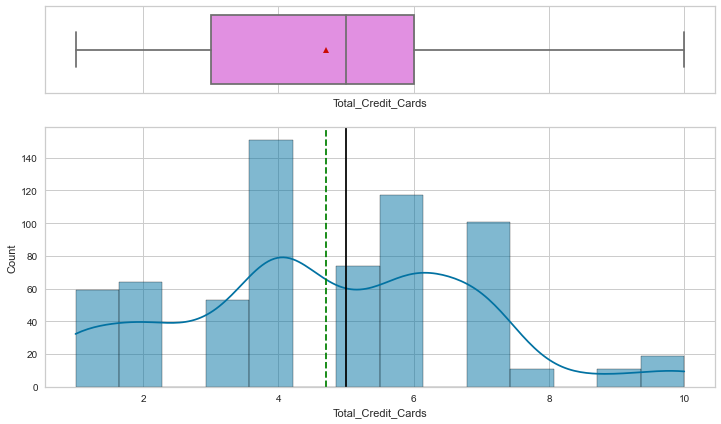

```
Total_visits_bank
```

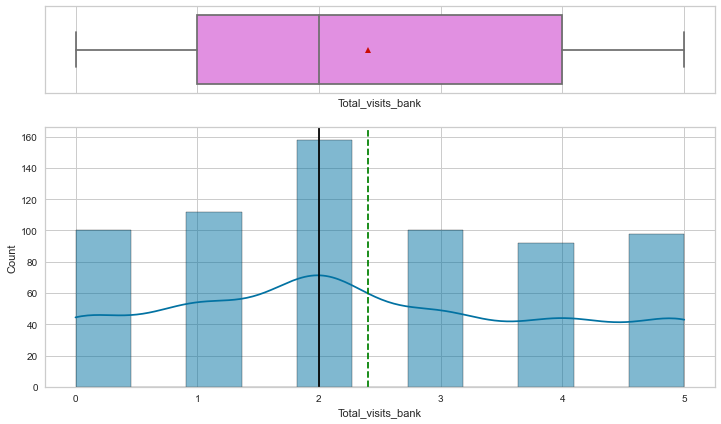

```
Total_visits_online
```

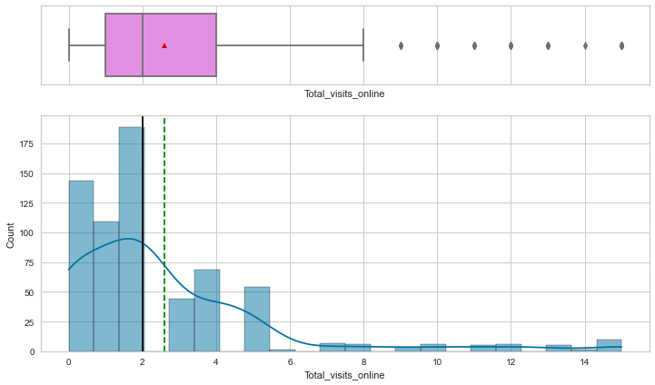

```
Total_calls_made
```

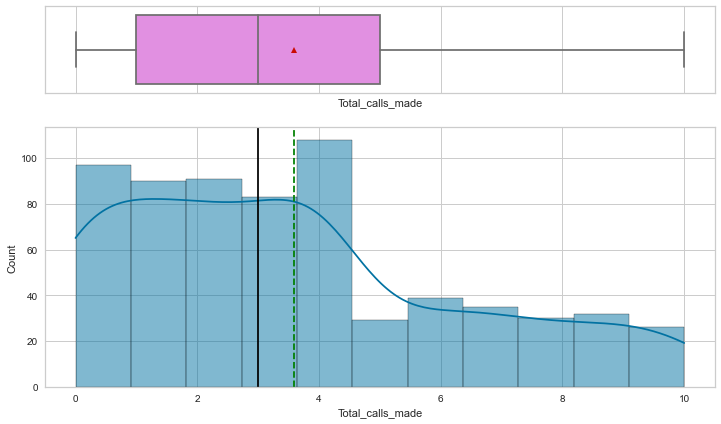

```python
## plot histogram and boxplot for the numerical features
num_cols = list(df.select_dtypes(include=["float", "int"]).columns)
for i in num_cols:
    print(i)
    histogram_boxplot(df, i)
    plt.show()
    print(
        " ****************************************************************** "
    )  ## To create a separator
```

Observations:

- Credit_Limit is severely skewed to the right, with several outliers to the right. There are a few customers with a high credit limit (>100,000) but no extreme points that are much further than the others.
- Total_Credit_Cards appears close to normally distributed with no outliers to the right or left.
- Total_visits_bank appears has a slight skew to the right but no outliers to the right or left and a small peak around 2.
- Total_visits_online is skewed to the right with several outliers to the right. There are a few customers who make a high number of online visits (>8), which is reasonable.
- Total_calls_made has a skew to the right with the mean greater than the median, but no outliers.

```
Total_Credit_Cards
```

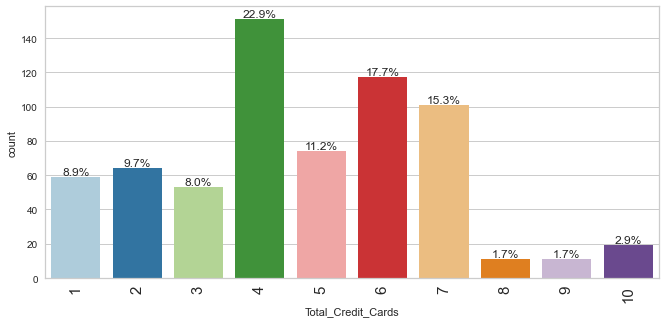

```
Total_visits_bank
```

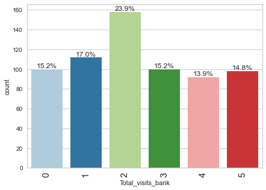

```
Total_visits_online
```

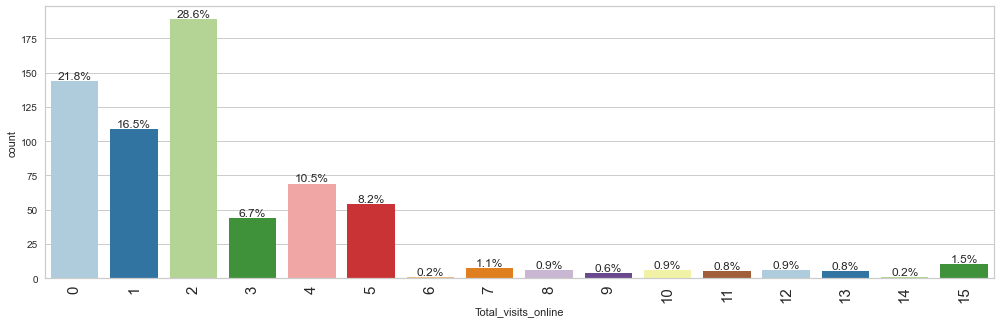

```
Total_calls_made
```

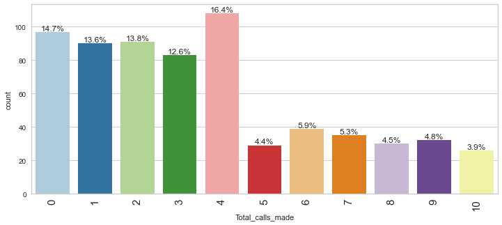

```python
## Barplot for features
bar_cols = [
    "Total_Credit_Cards",
    "Total_visits_bank",
    "Total_visits_online",
    "Total_calls_made",
]
for i in bar_cols:
    print(i)
    labeled_barplot(df, i, perc=True)
    plt.show()
    print(
        " ****************************************************************** "
    )  ## To create a separator
```

Observations:

- Most customers hold four credit cards (22.9%), make two bank visits (23.9%), two online visits (28.6%) and four calls (16.4%) yearly.
- Very few customers (~7.9%) make six or more online visits in a year.
- There is a significant drop in percentage of customers making five or more calls a year or holding eight or more credit cards. Most customers have fewer contacts or interactions with the bank.

### Bivariate Analysis

Explore relationships between variables.

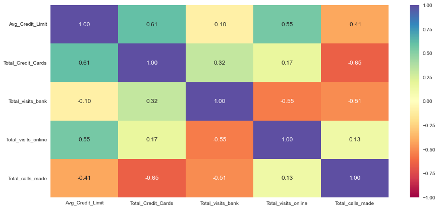

```python
# correlation plot
plt.figure(figsize=(15, 7))
sns.heatmap(df.corr(), annot=True, vmin=-1, vmax=1, fmt=".2f", cmap="Spectral")
plt.show()
```

Observations:

- Total_Credit_Cards and Avg_Credit_Limit have a moderately high positive correlation (0.61).
- Total_calls_made and Total_Credit_Cards have a moderately high negative correlation (-0.65).
- No two variables are very highly correlated to each other.

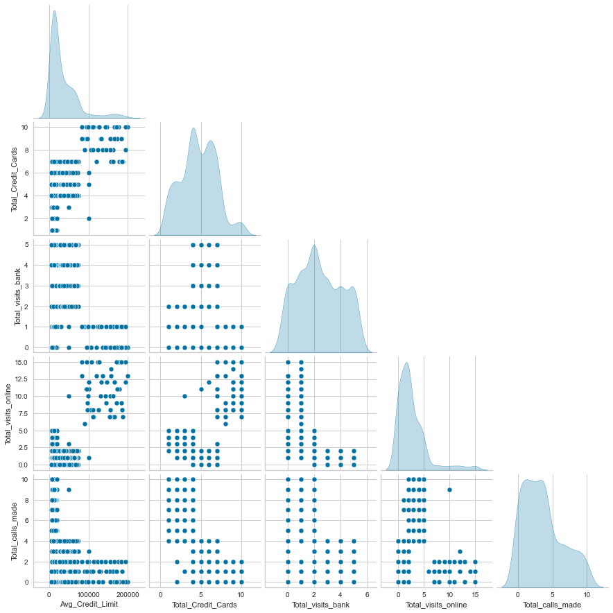

```python
# plot numerical features against each other
sns.pairplot(data=df, corner=True, diag_kind="kde")
plt.show()
```

### Outlier Detection and Treatment

- Both Avg_Credit_Limit and Total_visits_online had outliers.
- Total_visits_online ranged from 0 to 15 which is reasonable, so we will not treat these outliers.

```python
# look at outliers in Avg_Credit_Limit
df[df.Avg_Credit_Limit > 100000].sort_values(by="Total_Credit_Cards", ascending=False)
```

|  | Avg_Credit_Limit | Total_Credit_Cards | Total_visits_bank | Total_visits_online | Total_calls_made |
| --- | --- | --- | --- | --- | --- |
| 635 | 114000 | 10 | 1 | 7 | 2 |
| 636 | 126000 | 10 | 1 | 8 | 0 |
| 641 | 144000 | 10 | 0 | 10 | 2 |
| 630 | 200000 | 10 | 0 | 13 | 0 |
| 644 | 127000 | 10 | 1 | 15 | 1 |
| 627 | 146000 | 10 | 0 | 12 | 1 |
| 645 | 171000 | 10 | 0 | 15 | 0 |
| 623 | 166000 | 10 | 0 | 7 | 0 |
| 622 | 176000 | 10 | 1 | 15 | 2 |
| 649 | 112000 | 10 | 1 | 8 | 1 |
| 620 | 108000 | 10 | 0 | 15 | 1 |
| 650 | 195000 | 10 | 1 | 12 | 2 |
| 654 | 172000 | 10 | 1 | 9 | 1 |
| 658 | 172000 | 10 | 1 | 15 | 0 |
| 647 | 183000 | 9 | 0 | 9 | 2 |
| 651 | 132000 | 9 | 1 | 12 | 2 |
| 637 | 173000 | 9 | 1 | 11 | 0 |
| 612 | 157000 | 9 | 1 | 14 | 1 |
| 659 | 167000 | 9 | 0 | 12 | 2 |
| 626 | 156000 | 9 | 1 | 10 | 2 |
| 615 | 131000 | 9 | 1 | 10 | 1 |
| 621 | 166000 | 9 | 1 | 12 | 2 |
| 657 | 145000 | 8 | 1 | 9 | 1 |
| 617 | 136000 | 8 | 0 | 13 | 0 |
| 652 | 156000 | 8 | 1 | 8 | 0 |
| 648 | 111000 | 8 | 1 | 7 | 0 |
| 614 | 163000 | 8 | 1 | 7 | 1 |
| 634 | 106000 | 8 | 0 | 8 | 1 |
| 629 | 155000 | 8 | 0 | 7 | 2 |
| 631 | 195000 | 8 | 0 | 15 | 0 |
| 640 | 123000 | 8 | 1 | 15 | 2 |
| 638 | 153000 | 8 | 1 | 7 | 1 |
| 624 | 178000 | 7 | 0 | 11 | 0 |
| 619 | 158000 | 7 | 0 | 13 | 0 |
| 618 | 121000 | 7 | 0 | 13 | 2 |
| 639 | 184000 | 7 | 1 | 15 | 2 |
| 632 | 187000 | 7 | 1 | 7 | 0 |
| 633 | 163000 | 7 | 1 | 10 | 1 |
| 646 | 186000 | 7 | 0 | 8 | 1 |

- The customers that have an Avg_Credit_Limit above 100,000 hold at least 7 credit cards so these customers are more likely to have a high credit limit and spending habits. We will keep these values for the analysis.

### Feature Scaling

Feature scaling is specially relevant in machine learning models that compute some sort of distance metric, like most clustering methods. So, scaling should be done to avoid the problem of one feature dominating over others because the unsupervised learning algorithm uses distance to find the similarity between data points.

We will scale the variables in the datasets since they all have different ranges.

```python
# scale features
sc = StandardScaler()
scaled_df = pd.DataFrame(sc.fit_transform(df), columns=df.columns,)
scaled_df.head()
```

|  | Avg_Credit_Limit | Total_Credit_Cards | Total_visits_bank | Total_visits_online | Total_calls_made |
| --- | --- | --- | --- | --- | --- |
| 0 | 1.740187 | -1.249225 | -0.860451 | -0.547490 | -1.251537 |
| 1 | 0.410293 | -0.787585 | -1.473731 | 2.520519 | 1.891859 |
| 2 | 0.410293 | 1.058973 | -0.860451 | 0.134290 | 0.145528 |
| 3 | -0.121665 | 0.135694 | -0.860451 | -0.547490 | 0.145528 |
| 4 | 1.740187 | 0.597334 | -1.473731 | 3.202298 | -0.203739 |

```python
# check the mean
scaled_df.mean()
```

```
Avg_Credit_Limit       8.195465e-16
Total_Credit_Cards    -4.006223e-15
Total_visits_bank      1.157323e-16
Total_visits_online    1.944572e-16
Total_calls_made      -7.112156e-16
dtype: float64
```

```python
# check the standard deviation
scaled_df.std()
```

```
Avg_Credit_Limit       1.000758
Total_Credit_Cards     1.000758
Total_visits_bank      1.000758
Total_visits_online    1.000758
Total_calls_made       1.000758
dtype: float64
```

- Now all features have a mean of 0 and standard deviation of 1.

## Part 3: K Means Clustering

```
Number of Clusters: 1 	Average Distortion: 2.0069222262503614
Number of Clusters: 2 	Average Distortion: 1.4571553548514269
Number of Clusters: 3 	Average Distortion: 1.1466276549150365
Number of Clusters: 4 	Average Distortion: 1.0463825294774465
Number of Clusters: 5 	Average Distortion: 0.9905080751956661
Number of Clusters: 6 	Average Distortion: 0.9509131717441629
Number of Clusters: 7 	Average Distortion: 0.9105617048063307
Number of Clusters: 8 	Average Distortion: 0.8849797014612983
```

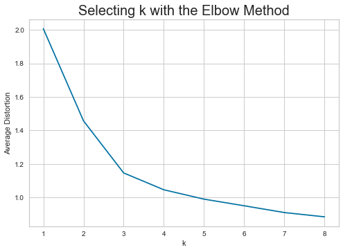

```python
# We will look at the results for 1-8 clusters
clusters = range(1, 9)  # define # of clusters
meanDistortions = []  # Create a empty list

for k in clusters:
    model = KMeans(n_clusters=k)  # Initialize KMeans
    model.fit(scaled_df)  # Fit kMeans on the data
    prediction = model.predict(scaled_df)  # Predict the model on the data
    distortion = (
        sum(np.min(cdist(scaled_df, model.cluster_centers_, "euclidean"), axis=1))
        / scaled_df.shape[0]  # Find distortion
    )

    meanDistortions.append(
        distortion
    )  # Append distortion values to the empty list created above

    print("Number of Clusters:", k, "\tAverage Distortion:", distortion)

plt.plot(clusters, meanDistortions, "bx-")
plt.xlabel("k")  # Title of X-axis
plt.ylabel("Average Distortion")  # Title of y-axis
plt.title("Selecting k with the Elbow Method", fontsize=20)  # Title of the plot
```

- There appears to be a clear elbow at K=3 in the elbow plot.
- There is a drop in average distortion at K=4 as well.
- To make a better decision about the number of clusters, we can look at the silhouette score for different K values.

### Silhouette Score

Silhouette score is one of the methods for evaluating the quality of clusters created using clustering algorithms such as K-Means. It is a measurement of how similar points within a cluster are to each other compared to how similar those points are to neighboring clusters. Silhouette coefficients near +1 indicate that the sample is far away from the neighboring clusters.

```
For n_clusters = 2, silhouette score is 0.41842496663215445
For n_clusters = 3, silhouette score is 0.5157182558881063
For n_clusters = 4, silhouette score is 0.3556670619372605
For n_clusters = 5, silhouette score is 0.2717470361089752
For n_clusters = 6, silhouette score is 0.2553480159463278
For n_clusters = 7, silhouette score is 0.248175083050816
For n_clusters = 8, silhouette score is 0.22727688029681778
For n_clusters = 9, silhouette score is 0.2254996233860712
```

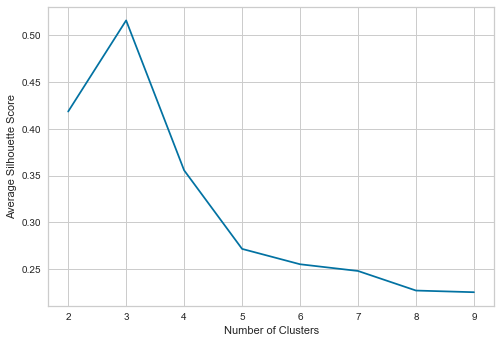

```python
sil_score = []  # Create empty list
cluster_list = list(range(2, 10))  # Creating a list of range from 2 to 10
for n_clusters in cluster_list:
    clusterer = KMeans(n_clusters=n_clusters)  # Initializing KMeans algorithm
    preds = clusterer.fit_predict((scaled_df))  # Predicting on the data
    # centers = clusterer.cluster_centers_
    score = silhouette_score(scaled_df, preds)  # Cacalculating silhouette score
    sil_score.append(score)  # Appending silhouette score to empty list created above
    print("For n_clusters = {}, silhouette score is {}".format(n_clusters, score))

plt.plot(cluster_list, sil_score)
plt.xlabel("Number of Clusters")
plt.ylabel("Average Silhouette Score")
```

- From the silhouette scores, it seems that 3 is a good value of k since it has the highest silhouette score (0.52).
- Let's do deeper investigation for different K values using SilhouetteVisualizer.

### SilhouetteVisualizer

Below are the points that every cluster needs to satisfy for selecting the optimal K-value.

- There should be no negative silhouette coefficent value
- All the clusters should cross the avg silhouette score
- All the clusters should have the different variations (width)
- All the clusters should have different silhouette score

Note:

1. Width of each cluster refers to the size of each cluster. (Number of data points present in each cluster)
2. Horizontal line refers to the Silhouette score of each cluster.
3. Dotted red line is an Average Silhouette score.

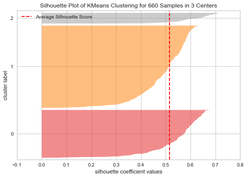

```python
# look at K=3 since it had the highest average silhouette score
# finding optimal no. of clusters with silhouette coefficients
visualizer = SilhouetteVisualizer(KMeans(3, random_state=1))
visualizer.fit(scaled_df)
visualizer.show()
```

- The plot for K=3 meets all criteria: no negative silhouette coefficient values, all clusters cross the avg silhouette score, all clusters have different widths, and all clusters have different silhouette scores.

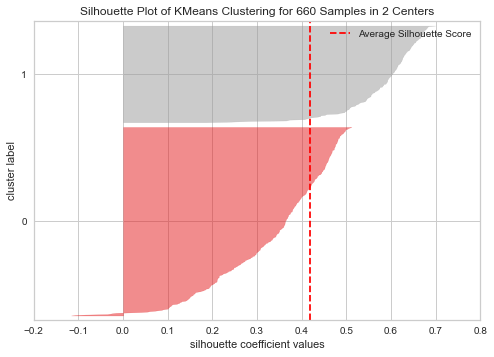

```python
# look at K=2 since it had the second highest average silhouette score
# finding optimal no. of clusters with silhouette coefficients
visualizer = SilhouetteVisualizer(KMeans(2, random_state=1))
visualizer.fit(scaled_df)
visualizer.show()
```

- The plot for K=2 shows negative silhouette for cluster 0, so it does not meet all the criteria.

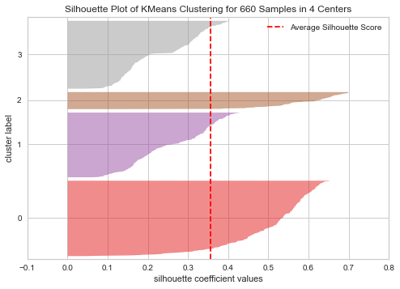

```python
# look at K=4 since it show a drop in the elbow plot
# finding optimal no. of clusters with silhouette coefficients
visualizer = SilhouetteVisualizer(KMeans(4, random_state=1))
visualizer.fit(scaled_df)
visualizer.show()
```

- The plot for K=4 does not meet all criteria since Clusters 0, 1 and 3 have similar widths and Clusters 1 and 3 have the same silhouette score.

**We can see from the plot above that K=3 clusters meet the requirements. So, let's take 3 as the appropriate no. of clusters (K) as the average silhouette score is the highest, the silhouette plot meets all the criteria, and there is a knick at 3 in the elbow curve.**

### Applying K Means Clustering for k=3

```python
# apply KMeans
kmeans = KMeans(n_clusters=3, random_state=1)
kmeans.fit(scaled_df)
```

```
KMeans(n_clusters=3, random_state=1)
```

```python
# adding kmeans cluster labels to the dataframe
df_k = df.copy()
df_k["K_means_segments"] = kmeans.labels_
```

### Cluster Profiling

```python
# find the mean of each cluster
cluster_profile = df_k.groupby("K_means_segments").mean()
```

```python
# find the number of points in each cluster
cluster_profile["count_in_each_segment"] = (
    df_k.groupby("K_means_segments")["Avg_Credit_Limit"].count().values
)
```

```python
# display cluster profiles with mean values and counts
cluster_profile.style.highlight_max(color="lightgreen", axis=0).highlight_min(
    color="yellow", axis=0
)
```

| K_means_segments | Avg_Credit_Limit | Total_Credit_Cards | Total_visits_bank | Total_visits_online | Total_calls_made | count_in_each_segment |
| --- | --- | --- | --- | --- | --- | --- |
| 0 | 12174.107143 | 2.410714 | 0.933036 | 3.553571 | 6.870536 | 224 |
| 1 | 33782.383420 | 5.515544 | 3.489637 | 0.981865 | 2.000000 | 386 |
| 2 | 141040.000000 | 8.740000 | 0.600000 | 10.900000 | 1.080000 | 50 |

- Cluster 2 has the smallest number of observations (50), followed by Cluster 0 (224 observations), and finally Cluster 1 (386 observations).

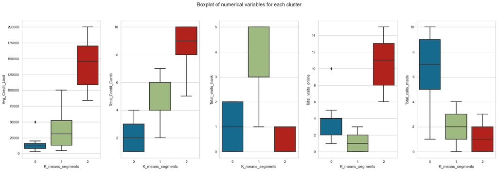

```python
# plot boxplot of the numerical variables for each cluster
fig, axes = plt.subplots(1, 5, figsize=(20, 7))
fig.suptitle("Boxplot of numerical variables for each cluster")
counter = 0
num_col = df.columns
for ii in range(5):
    sns.boxplot(ax=axes[ii], y=df_k[num_col[counter]], x=df_k["K_means_segments"])
    counter = counter + 1

fig.tight_layout(pad=2.0)
```

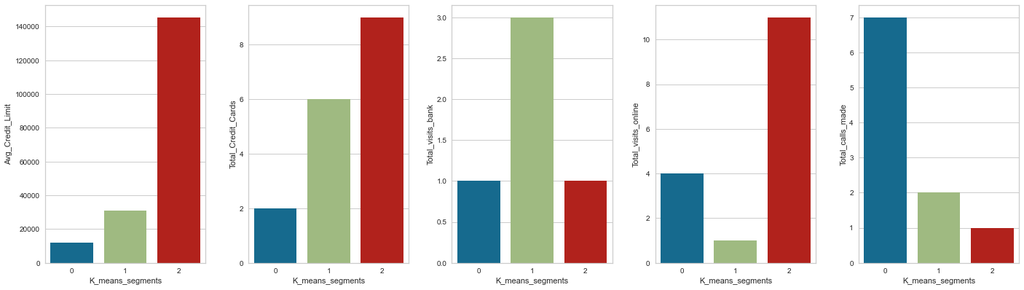

```python
# plot the median values for each variable and cluster
fig, axes = plt.subplots(1, 5, figsize=(20, 6))
for i in range(5):
    df_median = pd.DataFrame(df_k.groupby("K_means_segments")[num_col[i]].median())
    sns.barplot(ax=axes[i], y=df_median[df_median.columns[0]], x=df_median.index)
fig.tight_layout(pad=2.0)
```

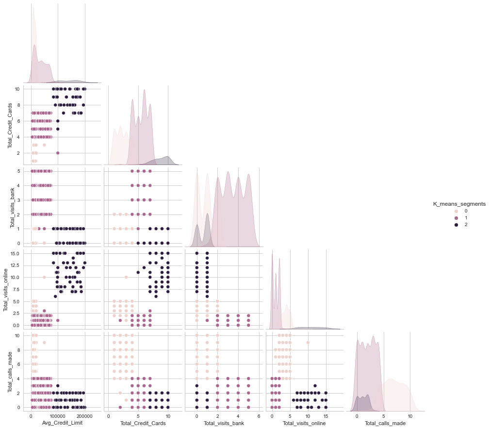

```python
# plot pair plot
sns.pairplot(data=df_k, corner=True, hue="K_means_segments")
plt.show()
```

- We see that the clusters are most separated from each other when looking at Total_visits_online, Avg_Credit_Limit and Total_Credit_Cards.
- Cluster 0 is unique in that it makes a high number of calls to the bank.
- Cluster 1 is unique in that it makes a high number of bank visits.

```python
# show statistics for Cluster 0
df_k[df_k.K_means_segments == 0].describe()
```

|  | Avg_Credit_Limit | Total_Credit_Cards | Total_visits_bank | Total_visits_online | Total_calls_made | K_means_segments |
| --- | --- | --- | --- | --- | --- | --- |
| count | 224.000000 | 224.000000 | 224.000000 | 224.000000 | 224.000000 | 224.0 |
| mean | 12174.107143 | 2.410714 | 0.933036 | 3.553571 | 6.870536 | 0.0 |
| std | 5249.048524 | 1.100783 | 0.803567 | 1.218978 | 1.990161 | 0.0 |
| min | 3000.000000 | 1.000000 | 0.000000 | 1.000000 | 1.000000 | 0.0 |
| 25% | 8000.000000 | 1.000000 | 0.000000 | 2.000000 | 5.000000 | 0.0 |
| 50% | 12000.000000 | 2.000000 | 1.000000 | 4.000000 | 7.000000 | 0.0 |
| 75% | 16000.000000 | 3.000000 | 2.000000 | 4.000000 | 9.000000 | 0.0 |
| max | 50000.000000 | 4.000000 | 2.000000 | 10.000000 | 10.000000 | 0.0 |

```python
# show statistics for Cluster 1
df_k[df_k.K_means_segments == 1].describe()
```

|  | Avg_Credit_Limit | Total_Credit_Cards | Total_visits_bank | Total_visits_online | Total_calls_made | K_means_segments |
| --- | --- | --- | --- | --- | --- | --- |
| count | 386.000000 | 386.000000 | 386.000000 | 386.000000 | 386.000000 | 386.0 |
| mean | 33782.383420 | 5.515544 | 3.489637 | 0.981865 | 2.000000 | 1.0 |
| std | 22169.460696 | 1.140069 | 1.135563 | 0.857167 | 1.430648 | 0.0 |
| min | 5000.000000 | 2.000000 | 1.000000 | 0.000000 | 0.000000 | 1.0 |
| 25% | 13000.000000 | 4.000000 | 3.000000 | 0.000000 | 1.000000 | 1.0 |
| 50% | 31000.000000 | 6.000000 | 3.000000 | 1.000000 | 2.000000 | 1.0 |
| 75% | 52000.000000 | 6.000000 | 5.000000 | 2.000000 | 3.000000 | 1.0 |
| max | 100000.000000 | 7.000000 | 5.000000 | 3.000000 | 4.000000 | 1.0 |

```python
# show statistics for Cluster 2
df_k[df_k.K_means_segments == 2].describe()
```

|  | Avg_Credit_Limit | Total_Credit_Cards | Total_visits_bank | Total_visits_online | Total_calls_made | K_means_segments |
| --- | --- | --- | --- | --- | --- | --- |
| count | 50.000000 | 50.000000 | 50.000000 | 50.000000 | 50.000000 | 50.0 |
| mean | 141040.000000 | 8.740000 | 0.600000 | 10.900000 | 1.080000 | 2.0 |
| std | 34457.877272 | 1.274715 | 0.494872 | 2.880264 | 0.876915 | 0.0 |
| min | 84000.000000 | 5.000000 | 0.000000 | 6.000000 | 0.000000 | 2.0 |
| 25% | 108750.000000 | 8.000000 | 0.000000 | 8.000000 | 0.000000 | 2.0 |
| 50% | 145500.000000 | 9.000000 | 1.000000 | 11.000000 | 1.000000 | 2.0 |
| 75% | 170000.000000 | 10.000000 | 1.000000 | 13.000000 | 2.000000 | 2.0 |
| max | 200000.000000 | 10.000000 | 1.000000 | 15.000000 | 3.000000 | 2.0 |

### Insights

- **Cluster 0**:
  - There are 224 obserations in this cluster.
  - Customers have a low credit limit (mean of 12,000) and low number of credit cards (mean of 2.4).
  - Customers made a low number of bank visits (mean of 0.9) yearly.
  - Customers made a low to moderate number of online visits (mean of 3.6) yearly.
  - Customers made a high number of calls to the bank or its customer service department (mean of 6.9).
- **Cluster 1**:
  - There are 386 observations in this cluster.
  - Customers have a moderate credit limit (mean of 34,000) and number of credit cards (mean of 5.5).
  - Customers made a high number of bank visits (mean of 3.5) yearly.
  - Customers made a low number of online visits (mean of 1) yearly.
  - Customers made a low to moderate number of calls to the bank or its customer service department (mean of 2).
- **Cluster 2**
  - There are 50 observations in this cluster.
  - Customers have a high credit limit (mean of 141,000) and number of credit cards (mean of 8.7).
  - Customers made a low number of bank visits (mean of 0.6) yearly.
  - Customers made a high number of online visits (mean of 10.9) yearly.
  - Customers made a low number of calls to the bank or its customer service department (mean of 1).

Overall, all the clusters cover different ranges of average credit limit and number of credit cards. The clusters are unique with their interactions with the bank as they each show a preference for different interaction types.

## Part 4: Hierarchical Clustering

### Cophentic Correlation

The cophenetic correlation coefficient is a correlation coefficient between the cophenetic distances (Dendrogramic distance) obtained from the tree, and the original distances used to construct the tree. It is a measure of how faithfully a dendrogram preserves the pairwise distances between the original unmodeled data points.

The cophenetic distance between two observations is represented in a dendrogram by the height of the link at which those two observations are first joined. That height is the distance between the two subclusters that are merged by that link.

Cophenetic correlation is the way to compare two or more dendrograms.

```python
# list of distance metrics
distance_metrics = ["euclidean", "chebyshev", "mahalanobis", "cityblock"]

# list of linkage methods
linkage_methods = ["single", "complete", "average", "weighted"]

high_cophenet_corr = 0
high_dm_lm = [0, 0]
cophenet_corr = []
linkage_methods_names = []
distance_metrics_names = []
# loop through distance metrics and linkage methods
for dm in distance_metrics:
    for lm in linkage_methods:
        Z = linkage(scaled_df, metric=dm, method=lm)
        c, coph_dists = cophenet(Z, pdist(scaled_df))
        print(
            "Cophenetic correlation for {} distance and {} linkage is {}.".format(
                dm.capitalize(), lm, c
            )
        )
        cophenet_corr.append(c)
        linkage_methods_names.append(lm)
        distance_metrics_names.append(dm)
        if high_cophenet_corr < c:
            high_cophenet_corr = c
            high_dm_lm[0] = dm
            high_dm_lm[1] = lm
```

```
Cophenetic correlation for Euclidean distance and single linkage is 0.7391220243806552.
Cophenetic correlation for Euclidean distance and complete linkage is 0.8599730607972423.
Cophenetic correlation for Euclidean distance and average linkage is 0.8977080867389372.
Cophenetic correlation for Euclidean distance and weighted linkage is 0.8861746814895477.
Cophenetic correlation for Chebyshev distance and single linkage is 0.7382354769296767.
Cophenetic correlation for Chebyshev distance and complete linkage is 0.8533474836336782.
Cophenetic correlation for Chebyshev distance and average linkage is 0.8974159511838106.
Cophenetic correlation for Chebyshev distance and weighted linkage is 0.8913624010768603.
Cophenetic correlation for Mahalanobis distance and single linkage is 0.7058064784553607.
Cophenetic correlation for Mahalanobis distance and complete linkage is 0.6663534463875355.
Cophenetic correlation for Mahalanobis distance and average linkage is 0.8326994115042136.
Cophenetic correlation for Mahalanobis distance and weighted linkage is 0.7805990615142518.
Cophenetic correlation for Cityblock distance and single linkage is 0.7252379350252723.
Cophenetic correlation for Cityblock distance and complete linkage is 0.8731477899179829.
Cophenetic correlation for Cityblock distance and average linkage is 0.896329431104133.
Cophenetic correlation for Cityblock distance and weighted linkage is 0.8825520731498188.
```

```python
# printing the combination of distance metric and linkage method with the highest cophenetic correlation
print(
    "Highest cophenetic correlation is {}, which is obtained with {} distance and {} linkage.".format(
        high_cophenet_corr, high_dm_lm[0].capitalize(), high_dm_lm[1]
    )
)
```

```
Highest cophenetic correlation is 0.8977080867389372, which is obtained with Euclidean distance and average linkage.
```

```python
# explore different linkage methods with Euclidean distance only
# list of linkage methods
linkage_methods = ["single", "complete", "average", "centroid", "ward", "weighted"]

high_cophenet_corr = 0
high_dm_lm = [0, 0]

for lm in linkage_methods:
    Z = linkage(scaled_df, metric="euclidean", method=lm)
    c, coph_dists = cophenet(Z, pdist(scaled_df))
    print("Cophenetic correlation for {} linkage is {}.".format(lm, c))
    cophenet_corr.append(c)
    linkage_methods_names.append(lm)
    distance_metrics_names.append("euclidean")
    if high_cophenet_corr < c:
        high_cophenet_corr = c
        high_dm_lm[0] = "euclidean"
        high_dm_lm[1] = lm
```

```
Cophenetic correlation for single linkage is 0.7391220243806552.
Cophenetic correlation for complete linkage is 0.8599730607972423.
Cophenetic correlation for average linkage is 0.8977080867389372.
Cophenetic correlation for centroid linkage is 0.8939385846326323.
Cophenetic correlation for ward linkage is 0.7415156284827493.
Cophenetic correlation for weighted linkage is 0.8861746814895477.
```

```python
# printing the combination of distance metric and linkage method with the highest cophenetic correlation
print(
    "Highest cophenetic correlation is {}, which is obtained with {} linkage.".format(
        high_cophenet_corr, high_dm_lm[1]
    )
)
```

```
Highest cophenetic correlation is 0.8977080867389372, which is obtained with average linkage.
```

```python
# create data frame of all the results and sort by largest to smallest cophenetic correlation
metrics = pd.DataFrame(
    [distance_metrics_names, linkage_methods_names, cophenet_corr],
).T
metrics.columns = ["Distance_Metric", "Linkage_Method", "Cophenetic_Corr"]
metrics = metrics.sort_values(by="Cophenetic_Corr", ascending=False).drop_duplicates()
metrics = metrics.reset_index(drop=True)
metrics
```

|  | Distance_Metric | Linkage_Method | Cophenetic_Corr |
| --- | --- | --- | --- |
| 0 | euclidean | average | 0.897708 |
| 1 | chebyshev | average | 0.897416 |
| 2 | cityblock | average | 0.896329 |
| 3 | euclidean | centroid | 0.893939 |
| 4 | chebyshev | weighted | 0.891362 |
| 5 | euclidean | weighted | 0.886175 |
| 6 | cityblock | weighted | 0.882552 |
| 7 | cityblock | complete | 0.873148 |
| 8 | euclidean | complete | 0.859973 |
| 9 | chebyshev | complete | 0.853347 |
| 10 | mahalanobis | average | 0.832699 |
| 11 | mahalanobis | weighted | 0.780599 |
| 12 | euclidean | ward | 0.741516 |
| 13 | euclidean | single | 0.739122 |
| 14 | chebyshev | single | 0.738235 |
| 15 | cityblock | single | 0.725238 |
| 16 | mahalanobis | single | 0.705806 |
| 17 | mahalanobis | complete | 0.666353 |

- Cophenetic correlation is maximum with Euclidean distance and average linkage.
- We will plot dendrograms for the top five distance metric/linkage methods that produced the highest cophenetic correlations.

### Dendrograms

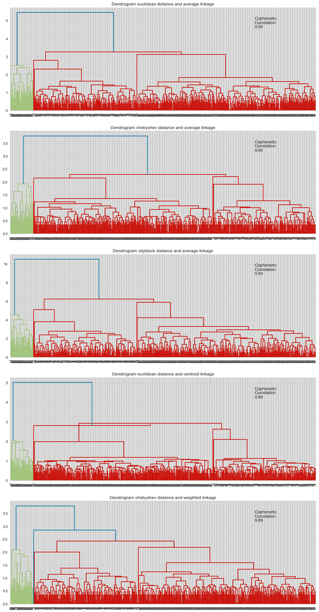

```python
# plot the top 5
# to create a subplot image
fig, axs = plt.subplots(5, 1, figsize=(15, 30))

# For each linkage method, we will plot the dendrogram and calculate the cophenetic correlation
for i in range(0, 5):
    Z = linkage(
        scaled_df,
        metric=metrics["Distance_Metric"][i],
        method=metrics["Linkage_Method"][i],
    )
    x = metrics["Distance_Metric"][i]
    y = metrics["Linkage_Method"][i]
    dendrogram(Z, ax=axs[i])
    axs[i].set_title(f"Dendrogram {x} distance and {y} linkage")

    coph_corr, coph_dist = cophenet(Z, pdist(scaled_df))
    axs[i].annotate(
        f"Cophenetic\nCorrelation\n{coph_corr:0.2f}",
        (0.80, 0.80),
        xycoords="axes fraction",
    )
```

- All methods agree that there is one distinct cluster as shown to the left of every graph. However, the other clusters do not have a clear separation.
- The highest vertical drop is shown in all the above graphs at two clusters.
- Let's explore different linkage methods with Euclidean distance only.

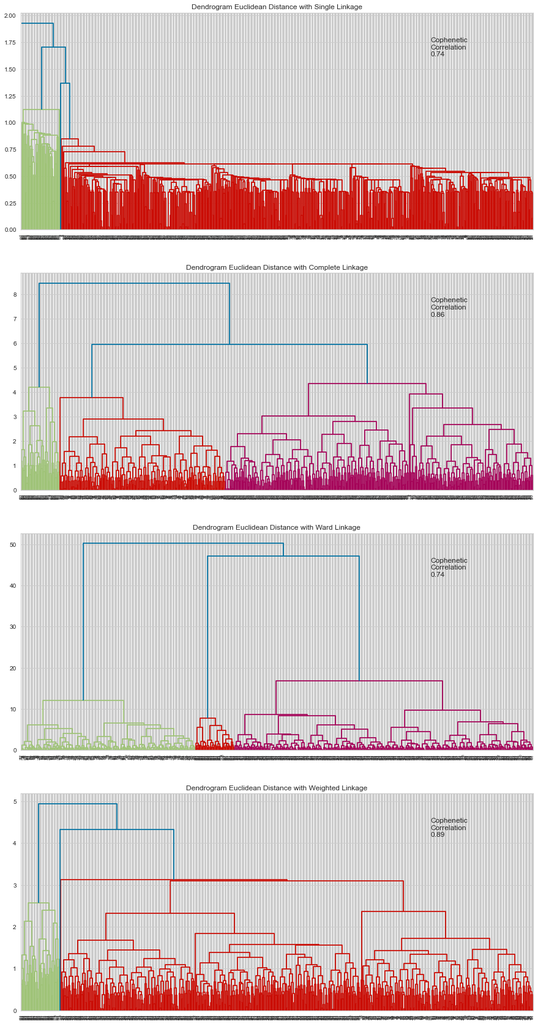

```python
# plot all other dendrograms for euclidean metric
# list of linkage methods
linkage_methods = ["single", "complete", "ward", "weighted"]

# to create a subplot image
fig, axs = plt.subplots(len(linkage_methods), 1, figsize=(15, 30))

# We will enumerate through the list of linkage methods above
# For each linkage method, we will plot the dendrogram and calculate the cophenetic correlation
for i, method in enumerate(linkage_methods):
    Z = linkage(scaled_df, metric="euclidean", method=method)

    dendrogram(Z, ax=axs[i])
    axs[i].set_title(
        f"Dendrogram Euclidean Distance with {method.capitalize()} Linkage"
    )

    coph_corr, coph_dist = cophenet(Z, pdist(scaled_df))
    axs[i].annotate(
        f"Cophenetic\nCorrelation\n{coph_corr:0.2f}",
        (0.80, 0.80),
        xycoords="axes fraction",
    )
```

- The dendrogram showing Euclidean with ward linkage showed the clearest separation of clusters, but a lower cophenetic correlation. The ward linkage graph shows the highest vertical drop at 3 clusters.
- We will compare Euclidean distance with both average linkage (clusters=2) and ward linkage (clusters=3).

### Silhouette Scores

```
For n_clusters = 2, silhouette score is 0.5703183487340514
For n_clusters = 3, silhouette score is 0.515922432650965
For n_clusters = 4, silhouette score is 0.47495143595793504
For n_clusters = 5, silhouette score is 0.44039753024783956
For n_clusters = 6, silhouette score is 0.4153547954831452
For n_clusters = 7, silhouette score is 0.4183775674672025
For n_clusters = 8, silhouette score is 0.34306710358280806
For n_clusters = 9, silhouette score is 0.3415486932890892
```

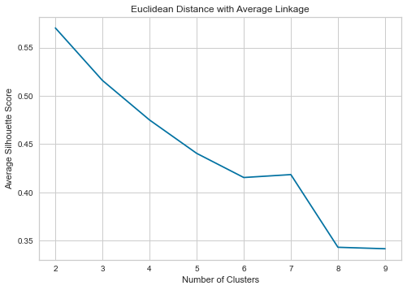

```python
# find silhouette scores for Euclidean distance and average linkage
sil_score = []  # Create empty list
cluster_list = list(range(2, 10))  # Creating a list of range from 2 to 10
for n_clusters in cluster_list:
    clusterer = AgglomerativeClustering(
        n_clusters=n_clusters, affinity="euclidean", linkage="average"
    )  # Initializing algorithm
    clusterer.fit(scaled_df)
    preds = clusterer.labels_  # Predicting on the data
    score = silhouette_score(scaled_df, preds)  # Cacalculating silhouette score
    sil_score.append(score)  # Appending silhouette score to empty list created above
    print("For n_clusters = {}, silhouette score is {}".format(n_clusters, score))

plt.plot(cluster_list, sil_score)
plt.xlabel("Number of Clusters")
plt.ylabel("Average Silhouette Score")
plt.title("Euclidean Distance with Average Linkage")
```

```
For n_clusters = 2, silhouette score is 0.417704147620949
For n_clusters = 3, silhouette score is 0.5147639589977819
For n_clusters = 4, silhouette score is 0.3480822581261928
For n_clusters = 5, silhouette score is 0.2569177732675831
For n_clusters = 6, silhouette score is 0.22677849725544041
For n_clusters = 7, silhouette score is 0.2162968685485734
For n_clusters = 8, silhouette score is 0.2186949061936046
For n_clusters = 9, silhouette score is 0.19527074669093417
```

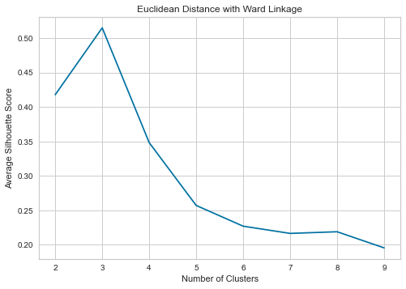

```python
sil_score = []  # Create empty list
cluster_list = list(range(2, 10))  # Creating a list of range from 2 to 10
for n_clusters in cluster_list:
    clusterer = AgglomerativeClustering(
        n_clusters=n_clusters, affinity="euclidean", linkage="ward"
    )  # Initializing algorithm
    clusterer.fit(scaled_df)
    preds = clusterer.labels_  # Predicting on the data
    score = silhouette_score(scaled_df, preds)  # Cacalculating silhouette score
    sil_score.append(score)  # Appending silhouette score to empty list created above
    print("For n_clusters = {}, silhouette score is {}".format(n_clusters, score))

plt.plot(cluster_list, sil_score)
plt.xlabel("Number of Clusters")
plt.ylabel("Average Silhouette Score")
plt.title("Euclidean Distance with Ward Linkage")
```

- As expected, silhouette scores are the highest for clusters = 2 (silhouette score of 0.57) for the average linkage and clusters = 3 (silhouette score of 0.51) for the ward linkage. However, the silhouette score for clusters=3 using average linkage was slightly higher than for ward linkage.
- We will go with Euclidean distance with average linkage using two clusters as this method produced the highest cophenetic correlation and higher average silhouette score. The dendrogram showed the highest vertical drop at two clusters as well.

### Applying Hierarchical Clustering for 2 clusters

```python
# apply Hierarchical Clustering with 2 clusters
HCmodel = AgglomerativeClustering(n_clusters=2, affinity="euclidean", linkage="average")
HCmodel.fit(scaled_df)
```

```
AgglomerativeClustering(linkage='average')
```

```python
# add cluster labels to dataset
df_h = df.copy()
df_h["HC_Clusters"] = HCmodel.labels_
```

```python
# create cluster profiles
cluster_profile_h = df_h.groupby("HC_Clusters").mean()
cluster_profile_h["count_in_each_segments"] = (
    df_h.groupby("HC_Clusters")["Avg_Credit_Limit"].count().values
)
```

```python
# lets display cluster profile
cluster_profile_h.style.highlight_max(color="lightgreen", axis=0)
```

| HC_Clusters | Avg_Credit_Limit | Total_Credit_Cards | Total_visits_bank | Total_visits_online | Total_calls_made | count_in_each_segments |
| --- | --- | --- | --- | --- | --- | --- |
| 0 | 25847.540984 | 4.375410 | 2.550820 | 1.926230 | 3.788525 | 610 |
| 1 | 141040.000000 | 8.740000 | 0.600000 | 10.900000 | 1.080000 | 50 |

- Cluster 1 has 50 observations, while all remaining observations were grouped in Cluster 0.

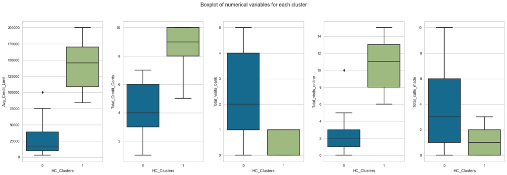

```python
# plot boxplot of the numerical variables for each cluster
fig, axes = plt.subplots(1, 5, figsize=(20, 7))
fig.suptitle("Boxplot of numerical variables for each cluster")
counter = 0
num_col = df.columns
for ii in range(5):
    sns.boxplot(ax=axes[ii], y=df_h[num_col[counter]], x=df_h["HC_Clusters"])
    counter = counter + 1

fig.tight_layout(pad=2.0)
```

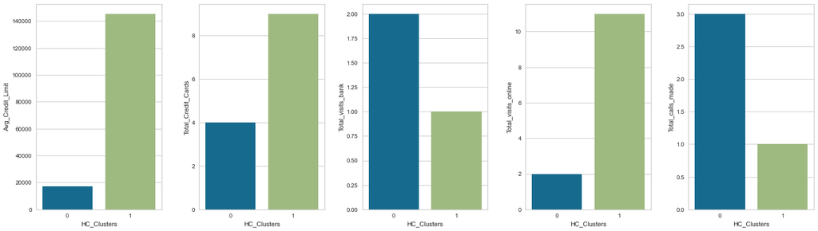

```python
# plot the median values for each variable and cluster
fig, axes = plt.subplots(1, 5, figsize=(20, 6))
for i in range(5):
    df_median = pd.DataFrame(df_h.groupby("HC_Clusters")[num_col[i]].median())
    sns.barplot(ax=axes[i], y=df_median[df_median.columns[0]], x=df_median.index)
fig.tight_layout(pad=2.0)
```

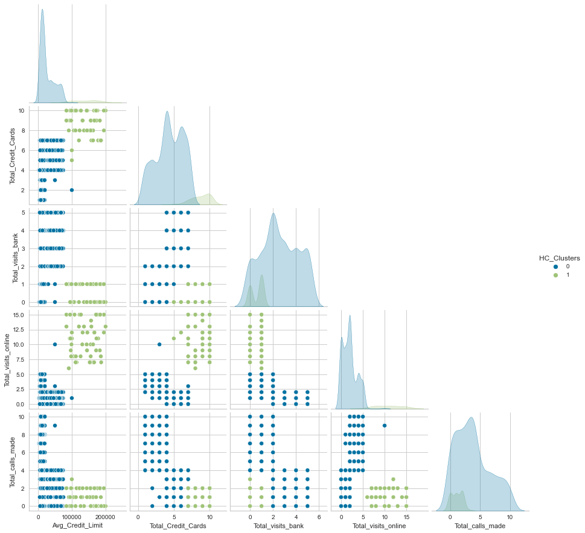

```python
# plot pair plot
sns.pairplot(data=df_h, corner=True, hue="HC_Clusters")
plt.show()
```

- We see that the clusters are most separated from each other when looking at Total_visits_online, Avg_Credit_Limit and Total_Credit_Cards.
- While Cluster 1 is focused on the lower range of Total_calls_made and Total_visits_bank, Cluster 0 spans all possible values. This is where having a third cluster may help in distinguishing these variable differences.

```python
# show statistics for Cluster 0
df_h[df_h.HC_Clusters == 0].describe()
```

|  | Avg_Credit_Limit | Total_Credit_Cards | Total_visits_bank | Total_visits_online | Total_calls_made | HC_Clusters |
| --- | --- | --- | --- | --- | --- | --- |
| count | 610.000000 | 610.000000 | 610.000000 | 610.000000 | 610.000000 | 610.0 |
| mean | 25847.540984 | 4.375410 | 2.550820 | 1.926230 | 3.788525 | 0.0 |
| std | 20723.721022 | 1.873254 | 1.604041 | 1.596219 | 2.874987 | 0.0 |
| min | 3000.000000 | 1.000000 | 0.000000 | 0.000000 | 0.000000 | 0.0 |
| 25% | 10000.000000 | 3.000000 | 1.000000 | 1.000000 | 1.000000 | 0.0 |
| 50% | 17000.000000 | 4.000000 | 2.000000 | 2.000000 | 3.000000 | 0.0 |
| 75% | 39000.000000 | 6.000000 | 4.000000 | 3.000000 | 6.000000 | 0.0 |
| max | 100000.000000 | 7.000000 | 5.000000 | 10.000000 | 10.000000 | 0.0 |

```python
# show statistics for Cluster 1
df_h[df_h.HC_Clusters == 1].describe()
```

|  | Avg_Credit_Limit | Total_Credit_Cards | Total_visits_bank | Total_visits_online | Total_calls_made | HC_Clusters |
| --- | --- | --- | --- | --- | --- | --- |
| count | 50.000000 | 50.000000 | 50.000000 | 50.000000 | 50.000000 | 50.0 |
| mean | 141040.000000 | 8.740000 | 0.600000 | 10.900000 | 1.080000 | 1.0 |
| std | 34457.877272 | 1.274715 | 0.494872 | 2.880264 | 0.876915 | 0.0 |
| min | 84000.000000 | 5.000000 | 0.000000 | 6.000000 | 0.000000 | 1.0 |
| 25% | 108750.000000 | 8.000000 | 0.000000 | 8.000000 | 0.000000 | 1.0 |
| 50% | 145500.000000 | 9.000000 | 1.000000 | 11.000000 | 1.000000 | 1.0 |
| 75% | 170000.000000 | 10.000000 | 1.000000 | 13.000000 | 2.000000 | 1.0 |
| max | 200000.000000 | 10.000000 | 1.000000 | 15.000000 | 3.000000 | 1.0 |

### Insights

- **Cluster 0**:
  - There are 610 obserations in this cluster.
  - Customers have a moderate credit limit (mean of 26,000) and moderate number of credit cards (mean of 4.4).
  - Customers made a moderate to high number of bank visits (mean of 2.6) yearly.
  - Customers made a low number of online visits (mean of 1.9) yearly.
  - Customers made a moderate to high number of calls to the bank or its customer service department (mean of 3.8).
- **Cluster 1**
  - There are 50 observations in this cluster.
  - Customers have a high credit limit (mean of 141,000) and number of credit cards (mean of 8.7).
  - Customers made a low number of bank visits (mean of 0.6) yearly.
  - Customers made a high number of online visits (mean of 10.9) yearly.
  - Customers made a low number of calls to the bank or its customer service department (mean of 1).

Overall, the clusters are distinct when it comes to average credit limit, number of credit cards, and number of online visits. There are similarities in clusters when looking at number of bank visits and number of calls to the bank since Cluster 0 spans all possible values.

## Part 5: Dimensionality Reduction using PCA for visualization

- Let's use PCA to reduce the data to two dimensions and visualize it to see how well-separated the clusters are.

```python
# setting the number of components to 2
pca = PCA(n_components=2)

# transforming data and storing results in a dataframe
X_reduced_pca = pca.fit_transform(scaled_df)
reduced_df_pca = pd.DataFrame(
    data=X_reduced_pca, columns=["Component 1", "Component 2"]
)
```

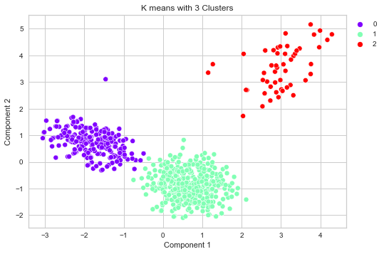

```python
# visualize in 2D plot for K Means and three clusters
sns.scatterplot(
    data=reduced_df_pca,
    x="Component 1",
    y="Component 2",
    hue=df_k["K_means_segments"],
    palette="rainbow",
)
plt.legend(bbox_to_anchor=(1, 1))
plt.title("K means with 3 Clusters")
```

- There appears to be clear separations in the clusters.

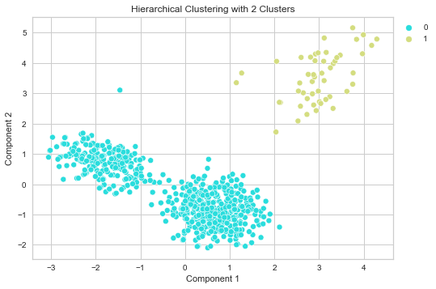

```python
# visualize in 2D plot for Hierarchical Clustering and two clusters
sns.scatterplot(
    data=reduced_df_pca,
    x="Component 1",
    y="Component 2",
    hue=df_h["HC_Clusters"],
    palette="rainbow",
)
plt.legend(bbox_to_anchor=(1, 1))
plt.title("Hierarchical Clustering with 2 Clusters")
```

- There appears to be clear separation in the clusters with Hierarchical Clustering and two clusters.
- We will visualize Hierarchical Clustering with 3 clusters as well to see how well it separates the lower cluster points.

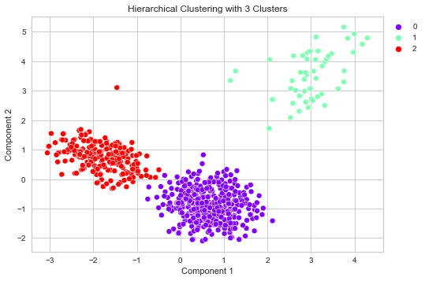

```python
# visualize Hierarchical Clustering with three clusters
# fit model for three clusters
HCmodel3 = AgglomerativeClustering(
    n_clusters=3, affinity="euclidean", linkage="average"
)
HCmodel3.fit(scaled_df)
# add labels to data frame
df_h3 = df.copy()
df_h3["HC_Clusters"] = HCmodel3.labels_
# visualize in 2D plot
sns.scatterplot(
    data=reduced_df_pca,
    x="Component 1",
    y="Component 2",
    hue=df_h3["HC_Clusters"],
    palette="rainbow",
)
plt.legend(bbox_to_anchor=(1, 1))
plt.title("Hierarchical Clustering with 3 Clusters")
```

- Hierarchical Clustering with 3 clusters appears to give very similar results to K Means with 3 clusters. The difference can be found on the points that border Clusters 0 and 2.

## Part 6: Compare Clusters

- K Means algorithm took much less time for execution compared to Hierarchical Clustering, which makes sense since Hierachical Clustering computes the distance between every pair of rows. The most time consuming portion was creating the dendrograms for Hierarchical Clustering.
- K Means obtained a higher number of recommended clusters (3) than Hierarchical Clustering (2).
- The average silhouette score for Hierarchical Clustering (0.57) was higher than K Means (0.52).
- Cluster 2 in K Means had the same observations as Cluster 1 in Hierarchical Clustering (50 observations).
- Both algorithms produced distinct clusters. Using two or three clusters showed the differences in average credit limit, number of credit cards, and number of online visits. There was a cluster at the lower range of these variables, and the other clusters were at the moderate or high end.
- However, three clusters was a better breakup of the data since it identified the difference in number of bank visits and number of calls. For example, Hierarchical Clustering with two clusters showed one cluster spanning all possible values for these variables. With K means and three clusters, we were able to see that Cluster 0 made a high number of calls and Cluster 1 made a high number of visits to the bank compared to other clusters.
- When comparing Hierarchical Clustering with 3 clusters and K Means with 3 clusters with PCA, the results were very similar. The only difference was in a few points that were on the borderline between two of the clusters.

## Part 7: Conclusions and Recommendations

## Summary/Insights

**Data Background:**

- There are 660 rows and 7 columns in the data.
- Duplicated values in Customer Key were kept in the data.
- All columns were int type.
- There were no missing values.

**Data Preprocessing:**

- The Sl_No and Customer Key columns were dropped as it isn’t important to the analysis.
- Outliers were identified in several of the highly skewed variables. However, these were kept as they were in a reasonable range.
- Standardized all numerical features with StandardScaler.

**Observations from EDA:**

- Most customers hold four credit cards (22.9%), make two bank visits (23.9%), two online visits (28.6%) and four calls (16.4%) yearly.
- Very few customers (~7.9%) make six or more online visits in a year.
- There is a significant drop in percentage of customers making five or more calls a year or holding eight or more credit cards. Most customers have fewer contacts or interactions with the bank.
- Total_Credit_Cards and Avg_Credit_Limit have a moderately high positive correlation (0.61).
- Total_calls_made and Total_Credit_Cards have a moderately high negative correlation (-0.65).
- No two variables are very highly correlated to each other.
- Generally, as a customer chooses more of one type of interaction, the less likely the customer will make more of any other type of interaction with the bank.

**Clustering Analysis:**

K Means

- Took 3 as the appropriate no. of clusters (K) as the average silhouette score is the highest, the silhouette plot meets all the criteria, and there is a knick at 3 in the elbow curve.
- Overall, all the clusters cover different ranges of average credit limit and number of credit cards. Cluster 2 prefers online interactions, Cluster 1 prefers bank visits, and Cluster 0 prefers calls.

Hierarchical Clustering

- Compared the cophenetic correlations of different distance metrics/linkage methods. Euclidean distance with average linkage had the highest value.
- Compared dendrograms of the top 5 cophenetic correlations as well as linkage methods for euclidean distance metric. Euclidean with ward had the most distinct clusters in the dendrogram.
- Compared the silhouette scores for Euclidean distance with average linkage vs ward linkage and ultimately chose Euclidean/average with 2 clusters.
- The clusters produced two distinct clusters except for total bank visits and total calls made.

Comparing Clusters

- K Means took less time and produced more clusters.
- The average silhouette score for Hierarchical Clustering (0.57) was higher than K Means (0.52).
- Cluster 2 in K Means had the same observations as Cluster 1 in Hierarchical Clustering (50 observations).
- Using three clusters vs. two clusters was a better breakup of the data.

## Recommendations

Recommendations below are based on K Means

- Cluster 0 consists of customers who have a lower credit limit, lower number of credit cards, and prefer making calls to the bank. The bank has the biggest opportunity to upsell services to these customers as they hold a low number of credit cards. The bank should focus on hiring and training customer service representatives to provide better quality call service and be ready to market to these customers when they call. Follow-ups and check ins can be done through text or phone call.
- Cluster 1 customers have a moderate credit limit, moderate number of credit cards, and prefer making visits to the bank. This was the largest group of customers. This is also an opportunity to upsell services. These customers prefer in-person interactions, so it is important to be personable. The bank can look at making these customers more comfortable when they visit the bank like offering a beverage and making light conversation. Schedule follow-ups visits as needed and provide information through mail as well.
- Cluster 2 customers have a high credit limit and high number of credit cards and prefer online visits. Since these are already high credit users, the bank should focus on promoting other banking offers like loans to these customers. Since these customers seem to prefer digital transcations, follow up with users through e-mail.
- Since high credit users prefer and continue using online services, it may be good to encourage online banking services to the other groups of customers as well.
- To better analyze how to improve service to customers, it is recommended that the bank conduct surveys or obtain ratings from customers after each interaction. Tracking this metric will help show if there is an improvement.